# P2: Investigate a Dataset (Titanic)

## Data Preparation & Cleaning

#### Import Libraries & Apply Settings

We're going to examine the titanic data contained in `titanic-data.csv` in several stages, the first being data preparation and cleaning. To begin with we'll need to load modules and apply settings we'll use throughout our analysis:

```python
# ----------------------------------------------------------------------
# - Load required libraries; apply global settings
# ----------------------------------------------------------------------

import functools
import warnings

import numpy as np
import pandas as pd
import matplotlib.pyplot as plt
import seaborn as sns

%matplotlib inline
sns.set(style="white", color_codes=True, context='notebook')

# suppress certain warnings for presentation (e.g. `set_tight_layout`)
warnings.simplefilter('ignore')

# ----------------------------------------------------------------------
```

#### Define Utility Functions

We can now define utility functions for later use. Using functions rather than cut-and-paste repetition tends to ease the understanding and maintenance of code. In a presentation of this sort it also has the advantage of making code somewhat less verbose.

```python
# ----------------------------------------------------------------------
# - Define utility functions for later use
# ----------------------------------------------------------------------

def get_labels(s, ascending=True):
    '''Extract an ordered list of unique labels from a pd.Series.'''

    return s.sort_values(ascending=ascending).unique().tolist()


def format_float(x, format_str='{0:.2f}'):
    '''Format a numeric value with the given format string.'''

    return format_str.format(x)


def format_pct(x, format_str='{0:.2%}'):
    '''Format a percentage with the given format string.'''

    return format_str.format(x)


def get_munging_stats(df, print_=True):
    '''Print or return munging statistics for a data frame.'''

    munging_stats = pd.concat([df.apply(lambda s: s.isnull()
                                                   .mean())
                                 .apply(format_pct)
                                 .to_frame('Percent Null'),
                               df.apply(lambda s: s.isnull()
                                                   .sum())
                                 .to_frame('Null Count'),
                               df.dtypes
                                 .to_frame('Data Type'),
                               df.apply(lambda s: s.nunique())
                                 .to_frame('Unique Value Count')],
                              axis=1)

    if print_:
        print '-' * 80
        print 'Summary of Data Munging Statistics:'
        print '-' * 80
        print munging_stats
        print '-' * 80, '\n'
    else:
        return munging_stats


def add_col_on_mapping(df, in_col, out_col, m, int_col=True):
    '''Adds a column to a dataframe based on a dictionary mapping.'''

    df[out_col] = df[in_col].apply(lambda k, m=m: m.get(k, np.nan))
    if int_col:
        df[out_col] = pd.Series(df[out_col], dtype='int64')

# ----------------------------------------------------------------------
```

#### Load Data

Now we're ready to load our data. While we're at it we'll change the column names to lowercase to conform to Python variable naming/attribute access conventions (e.g. `my_data.my_column` vs. `my_data.MyColumn`). We'll also replace the arbitrary index `pd.read_csv` creates with a column from the dataset, but only after we've checked that it's actually a unique index. (Assigning an index automatically with `pd.read_csv` works, too, but only if you're sure your dataset has a unique index does it work without potential confusion later in the analysis.)

```python
# ----------------------------------------------------------------------
# - Load data, lowercase column names, re-index
# ----------------------------------------------------------------------

titanic = pd.read_csv('titanic-data.csv')
print 'Column names before:'
for column in titanic:
    print '\t',repr(column)

titanic.columns = titanic.columns.str.lower()
print 'Column names after:'
for column in titanic:
    print '\t',repr(column)

try:
    assert titanic.passengerid.nunique() == titanic.shape[0]
except AssertionError:
    print 'Note: `passengerid` contains duplicate values.'
    print 'No re-indexing performed.'
else:
    titanic.index = pd.Index(titanic.passengerid)
    del titanic['passengerid']
    print 'Re-indexing performed.'
finally:
    print 'New index name: {!r}'.format(titanic.index.name)
    print '\n'

# ----------------------------------------------------------------------
```

```
Column names before:
	'PassengerId'
	'Survived'
	'Pclass'
	'Name'
	'Sex'
	'Age'
	'SibSp'
	'Parch'
	'Ticket'
	'Fare'
	'Cabin'
	'Embarked'
Column names after:
	'passengerid'
	'survived'
	'pclass'
	'name'
	'sex'
	'age'
	'sibsp'
	'parch'
	'ticket'
	'fare'
	'cabin'
	'embarked'
Re-indexing performed.
New index name: 'passengerid'
```

#### Inspect Data

Looking at the output of the last cell we can see the results are about what we expected. Next we'll look at some sample records and examine data munging statistics in order to see how we should proceed:

```python
# ----------------------------------------------------------------------
# - Show sample records
# ----------------------------------------------------------------------

print titanic.sample(10)

# ----------------------------------------------------------------------
```

```
             survived  pclass  \
passengerid
124                 1       2
764                 1       1
771                 0       3
543                 0       3
871                 0       3
320                 1       1
406                 0       2
639                 0       3
459                 1       2
413                 1       1

                                                          name     sex   age  \
passengerid
```

[output cut: 23 more lines]

```python
# ----------------------------------------------------------------------
# - Get munging statistics
# ----------------------------------------------------------------------

get_munging_stats(titanic)

# ----------------------------------------------------------------------
```

```
--------------------------------------------------------------------------------
Summary of Data Munging Statistics:
--------------------------------------------------------------------------------
         Percent Null  Null Count Data Type  Unique Value Count
survived        0.00%           0     int64                   2
pclass          0.00%           0     int64                   3
name            0.00%           0    object                 891
sex             0.00%           0    object                   2
age            19.87%         177   float64                  88
sibsp           0.00%           0     int64                   7
parch           0.00%           0     int64                   7
ticket          0.00%           0    object                 681
fare            0.00%           0   float64                 248
cabin          77.10%         687    object                 147
embarked        0.22%           2    object                   3
--------------------------------------------------------------------------------
```

Our sample data seems okay. The munging statistics show us the presence of missing data (i.e. `np.nan` values) in `age`, `cabin`, and `embarked`. Of these `cabin` appears the most-affected: we'll need to be cautious about summary statistics using `cabin` or values derived therefrom. The number of unique values also gives us a clue to the potential utility of categorical columns (for instance, as it stands, `cabin` has too many labels for useful comparisons). We won't replace null values at this point, though, as what to replace a null with (for best results) depends a lot on the details of the questions we ask.

#### Add Both Integer & Descriptive Columns

Depending on how we choose to look at the categorical variables in our dataset it may be useful to have both integer and text labels (i.e. {0,1} vs. {'female', 'male'}). Both conventions have advantages. (For example, for binary data or data that has a natural ordering integers can allow us to use the categories in various analytical functions.) We'll apply that transformation now in order to avoid upsetting the flow of our analysis later:

```python
# ----------------------------------------------------------------------
# - Add integer representations and descriptive labels
# ----------------------------------------------------------------------

in_cols = ['embarked', 'embarked', 'sex',
           'sex', 'pclass', 'survived']

out_cols = ['embarked', 'embarked_label', 'sex',
            'sex_label', 'pclass_label', 'survived_label']

mappings = [{'S': 1, 'C': 2,'Q': 3},
            {1: 'Southampton', 2: 'Cherbourg', 3: 'Queenstown'},
            {'female': 0, 'male': 1},
            {0: 'Female', 1: 'Male'},
            {1: '1st', 2: '2nd', 3: '3rd'},
            {0: 'No', 1: 'Yes'}]

int_cols = [True, False, True, False, False, False]

zipper = zip(in_cols, out_cols, mappings, int_cols)
for in_col, out_col, mapping, int_col in zipper:
    add_col_on_mapping(titanic, in_col=in_col, out_col=out_col,
                       m=mapping, int_col=int_col)

# ----------------------------------------------------------------------
```

#### Explore Latent Variables

There are a number of latent variables in the titanic data that we might be able to extract with regular expressions. We'll do that now for the `name` and `cabin` columns. While in this case we didn't end up using them further on in our analysis, the habit of extracting useful-looking latent info from text variables could lead us to some insights for other projects.

```python
# ----------------------------------------------------------------------
# - Extract `title` from `name`
# ----------------------------------------------------------------------

title_pat = r'(?:[^,]+)(?:,\s*the\s*|,\s*)([a-zA-Z]+\.?)'
titanic['title'] = titanic.name.str.extract(pat=title_pat, expand=False)

# ----------------------------------------------------------------------
```

```python
# ----------------------------------------------------------------------
# - Extract `deck_label` from `cabin` and add integer `deck` column
# ----------------------------------------------------------------------

# removes invalid 'T' label from `cabin` while getting first letters
deck_pat = r'(^[^T])'
titanic['deck_label'] = titanic.cabin.str.extract(pat=deck_pat,
                                                  expand=False)

deck_labels = get_labels(titanic.loc[~titanic.deck_label.isnull(),
                                     'deck_label'])
mapping = {val: idx for idx, val in enumerate(deck_labels)}
add_col_on_mapping(titanic, in_col='deck_label', out_col='deck',
                   m=mapping,int_col=True)

# ----------------------------------------------------------------------
```

#### Represent Continuous Variables as Bins

It may be useful to look at continuous variables as binned categories instead. We'll transform `age` into a binned variable for later use. Another good candidate would be `fare`, though we won't be using that in our analysis.

```python
# ----------------------------------------------------------------------
# - Add `age_range` column
# ----------------------------------------------------------------------

range_bins = range(0, int(titanic.age.max()) + 5, 5)

bin_names = [str(range_bin)
             for range_bin in range_bins]

# Somewhat involved, but boils down to creating 'X to Y' labels
range_labels = [' to '.join(bin_names[idx1:idx2])
                for idx1, idx2 in zip(range(0,len(range_bins) - 1),
                                      range(2,len(range_bins) + 1))]

titanic['age_range'] = pd.cut(titanic.age, bins=range_bins,
                              labels=range_labels,
                              include_lowest=False, right=True)

# ----------------------------------------------------------------------
```

#### Inspect Data

Let's take another look at some sample data and our data munging statistics to make sure everything looks okay. We're not going to be able to detect really subtle errors this way, but larger-scale mistakes will show up. If any of our sample data looks odd or the munging statistics are wildly different from the data before transformation, we'll know we've made a mistake in our data preparation and cleaning.

```python
# ----------------------------------------------------------------------
# - Show sample records
# ----------------------------------------------------------------------

print titanic.sample(10)

# ----------------------------------------------------------------------
```

```
             survived  pclass  \
passengerid
536                 1       2
316                 1       3
883                 0       3
709                 1       1
641                 0       3
395                 1       3
456                 1       3
878                 0       3
342                 1       1
235                 0       2

                                                          name  sex   age  \
passengerid
```

[output cut: 49 more lines]

```python
# ----------------------------------------------------------------------
# - Check munging statistics again
# ----------------------------------------------------------------------

get_munging_stats(titanic)

# ----------------------------------------------------------------------
```

```
--------------------------------------------------------------------------------
Summary of Data Munging Statistics:
--------------------------------------------------------------------------------
               Percent Null  Null Count Data Type  Unique Value Count
survived              0.00%           0     int64                   2
pclass                0.00%           0     int64                   3
name                  0.00%           0    object                 891
sex                   0.00%           0     int64                   2
age                  19.87%         177   float64                  88
sibsp                 0.00%           0     int64                   7
parch                 0.00%           0     int64                   7
ticket                0.00%           0    object                 681
fare                  0.00%           0   float64                 248
cabin                77.10%         687    object                 147
embarked              0.22%           2   float64                   3
embarked_label        0.22%           2    object                   3
sex_label             0.00%           0    object                   2
pclass_label          0.00%           0    object                   3
survived_label        0.00%           0    object                   2
title                 0.00%           0    object                  17
deck_label           77.22%         688    object                   7
deck                 77.22%         688   float64                   7
age_range            19.87%         177  category                  16
--------------------------------------------------------------------------------
```

The sample data appears as we expected. We can observe the following from the munging statistics:

- `age_range` and `age` have identical null counts; we can be fairly sure our transformation did what we wanted it to
- `embarked` and `embarked_label` also have identical null counts; the same conclusion can be reached
- `deck_label` and `deck` have one more null than `cabin`; this is to be expected considering we removed the one 'T' value from `cabin` (due to the Titanic not having a 'T' deck)

## Data Exploration

Now that we have our data in a useful form to work with, it's time to explore! As a (somewhat arbitrary) limit on the length and complexity of this project, we're going to restrict ourselves to the variables `survived`, `age`, `pclass`, and `sex`. We'll be focusing on the following questions:

- How is passenger age distributed?
- Does passenger age vary by class and gender?
- How does passenger survival vary by age, class, and gender?

It's important to remember as we go that any conclusions we reach are inherently tentative. Correlation isn't synonymous with causation. For example, should we discover that older aboard the Titanic survived more often, our conclusion should not be "Increase age causes higher survival rates in early 20th century cruise ship disasters!" We should simply note the correlation between the two variables, taking it as a hint that there might be something to explore with a more rigorous analysis. Essentially, we're able to explain what happened in great detail, but not why it happened.

### How is passenger age distributed?

```python
# ----------------------------------------------------------------------
# - Get summary statistics for `age`
# ----------------------------------------------------------------------

stats = (titanic.age.describe()
                .apply(format_float)
                .to_frame(''))
stats.index = stats.index.str.title()

print "Summary of Age:"
print stats

# ----------------------------------------------------------------------
```

```
Summary of Age:

Count  714.00
Mean    29.70
Std     14.53
Min      0.42
25%     20.12
50%     28.00
75%     38.00
Max     80.00
```

```python
# ----------------------------------------------------------------------
# - Get summary statistics for `age_range`
# ----------------------------------------------------------------------

stats = (titanic.groupby('age_range')['name']
                          .count()
                          .to_frame('Count'))
stats.index.name = stats.index.name.replace('_', ' ').title()

print "Summary by Age Range:\n"
print stats

# ----------------------------------------------------------------------
```

```
Summary by Age Range:

           Count
Age Range
0 to 5        44
5 to 10       20
10 to 15      19
15 to 20      96
20 to 25     122
25 to 30     108
30 to 35      88
35 to 40      67
40 to 45      47
45 to 50      39
50 to 55      24
55 to 60      18
60 to 65      14
65 to 70       3
70 to 75       4
75 to 80       1
```

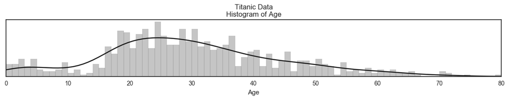

```python
# ----------------------------------------------------------------------
# - Plot a histogram of `age`
# ----------------------------------------------------------------------

fig, ax = plt.subplots(1, 1)
bins = list(range(0, int(titanic.age.max()) + 1, 1))

sns.distplot(titanic.loc[~titanic.age.isnull(), 'age'], bins=bins,
             hist=True, kde=True, hist_kws={'alpha': 0.25},
             kde_kws={'shade': False}, color='k', ax=ax)

ax.set_xlabel('Age')
ax.set_xlim(0, 80)
ax.set_ylabel('')
# marginal density labels don't add anything useful to this plot
ax.set_yticklabels([])
ax.set_title('Titanic Data\n' +
             'Histogram of Age')

fig.set_figwidth(12)
fig.set_figheight(2.5)
# `set_tight_layout` is (unintuitively) needed to get the right look
fig.set_tight_layout(tight={'h_pad': 0})

# ----------------------------------------------------------------------
```

We can make the following observations:

- We have more young children and fewer pre-teens than we'd expect given a normal distribution of ages (i.e. the 'bump' between zero and five years)
- We have more middle aged and elderly passengers than we'd expect given a normal distribution of ages (i.e. the fat tail starting at forty years)
- Despite these deviations from a normal distribution, mean and median age are close
- The typical passenger is between twenty and thirty years old

At this point, if we had to characterize the distribution, right skewed would be most appropriate. However, I think the observations above give a better idea of what's going on.

### Does passenger age vary by class and gender?

```python
# ----------------------------------------------------------------------
# - Get summary statistics for `age` by `sex` and `pclass`
# ----------------------------------------------------------------------

stats = (titanic.groupby(['sex_label', 'pclass_label'])['age']
                .agg(['min', 'mean', 'max', 'std'])
                .apply(lambda s: s.apply(format_float)))
stats.columns = ['Min', 'Mean', 'Max', 'StDev']
stats.index.names = ['Gender', 'Passenger Class']

print "Summary of Age by Gender & Passenger Class:\n\n",
print stats

# ----------------------------------------------------------------------
```

```
Summary of Age by Gender & Passenger Class:

                         Min   Mean    Max  StDev
Gender Passenger Class
Female 1st              2.00  34.61  63.00  13.61
       2nd              2.00  28.72  57.00  12.87
       3rd              0.75  21.75  63.00  12.73
Male   1st              0.92  41.28  80.00  15.14
       2nd              0.67  30.74  70.00  14.79
       3rd              0.42  26.51  74.00  12.16
```

Yes, passenger age varies by class and gender. So far it appears that...

- The typical age of higher social status classes was higher
- The typical female passenger was younger
- The typical female passenger for a given class was younger
- The oldest male passengers were older and the youngest younger for a given class

```python
# ----------------------------------------------------------------------
# - Get summary statistics for `age_range` by `sex` and `pclass`
# ----------------------------------------------------------------------

stats = (titanic.groupby('age_range')[['sex', 'pclass']]
                          .mean()
                          .apply(lambda s: s.apply(format_float)))

stats.index.name = stats.index.name.replace('_', ' ').title()
stats.columns = ['Mean Gender {0: F, 1: M}',
                 'Mean Passenger Class']

print "Summary of Gender & Passenger Class by Age Range:\n"
print stats
# ----------------------------------------------------------------------
```

```
Summary of Gender & Passenger Class by Age Range:

          Mean Gender {0: F, 1: M} Mean Passenger Class
Age Range
0 to 5                        0.52                 2.57
5 to 10                       0.50                 2.80
10 to 15                      0.37                 2.58
15 to 20                      0.65                 2.52
20 to 25                      0.63                 2.41
25 to 30                      0.67                 2.36
30 to 35                      0.66                 2.22
35 to 40                      0.63                 1.93
40 to 45                      0.62                 2.17
45 to 50                      0.67                 1.62
50 to 55                      0.67                 1.58
55 to 60                      0.67                 1.44
60 to 65                      0.79                 1.50
65 to 70                      1.00                 1.67
70 to 75                      1.00                 2.00
75 to 80                      1.00                 1.00
```

A different method of looking at the three variables, we can see that as passenger age increases, mean passenger class decreases (i.e. mean status increases) and mean sex increases (i.e. it's more likely that a passenger is male). It's interesting to note that the association between these three variables is least clear among young children, though.

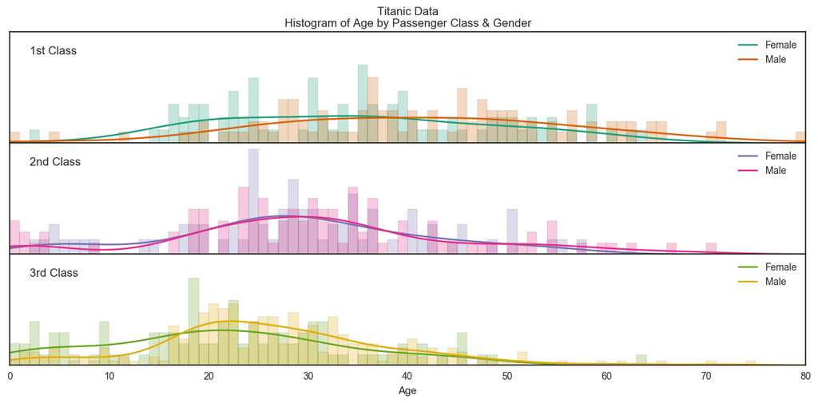

```python
# ----------------------------------------------------------------------
# - Plot `age` by `pclass` and `sex`
# ----------------------------------------------------------------------

fig, axes = plt.subplots(3, 1, sharex=True, sharey=True)

bins = list(range(0, int(titanic.age.max()) + 1, 1))

# see the utility function `get_labels`, above
pclasses = get_labels(titanic.pclass)
sexes = get_labels(titanic.sex)
class_annotations = ['{} Class'.format(label)
                     for label in get_labels(titanic.pclass_label)]
sex_labels = get_labels(titanic.sex_label)

# create color ID pairs to iterate over a palette
cidx_pairs = [(0, 1), (2, 3), (4, 5)]
palette = sns.color_palette("Dark2")


# the outor loop controls the three subplots
outer_zipper = enumerate(zip(pclasses, axes, cidx_pairs,
                             class_annotations))
for index, (pclass, ax, cidx_pair, class_annotation) in outer_zipper:

    # the inner loop draws two Seaborn plots onto each subplot
    inner_zipper = zip(sexes, cidx_pair, sex_labels)
    for sex, cidx, sex_label in inner_zipper:

        sns.distplot(titanic.loc[(titanic.pclass == pclass) &
                                 (titanic.sex == sex) &
                                 (~titanic.age.isnull()), 'age'],
                     bins=bins, hist=True, kde=True,
                     hist_kws={'alpha': 0.25},
                     kde_kws={'shade': False, 'label': sex_label},
                     color=palette[cidx], ax=ax)

    ax.annotate(class_annotation, (2, 0.08))
    ax.set_yticklabels([])
    ax.set_xlim(0, 80)

    # assign per-subplot settings
    if index == 0:
        ax.set_title('Titanic Data\n' +
                     'Histogram of Age by Passenger Class & Gender')
        ax.set_xlabel('')
    elif index == 1:
        ax.set_xlabel('')
    elif index == 2:
        ax.set_xlabel('Age')


fig.set_figwidth(12)
fig.set_figheight(6)
fig.set_tight_layout(tight={'h_pad': 0})

# ----------------------------------------------------------------------
```

### How does passenger survival vary by age, class, and gender?

```python
# ----------------------------------------------------------------------
# - Get summary statistics for `survived` by `sex` and `pclass`
# ----------------------------------------------------------------------

stats = (titanic.groupby(['sex_label', 'pclass_label'])['survived']
                .mean()
                .apply(format_pct)
                .to_frame('Survival'))

stats.index.names = ['Gender', 'Passenger Class']

print "Summary of Survival by Gender & Passenger Class:\n"
print stats

# ----------------------------------------------------------------------
```

```
Summary of Survival by Gender & Passenger Class:

                       Survival
Gender Passenger Class
Female 1st               96.81%
       2nd               92.11%
       3rd               50.00%
Male   1st               36.89%
       2nd               15.74%
       3rd               13.54%
```

We're starting by looking at survival by gender and passenger class. Let's start going through the implications...

```python
# ----------------------------------------------------------------------
# - Get summary statistics for `sex` and `pclass` by `survived`
# ----------------------------------------------------------------------

stats = (titanic.groupby(['survived_label'])[['sex', 'pclass']]
                .mean()
                .apply(lambda s: s.apply(format_float)))

stats.columns = ['Mean Gender', 'Mean Passenger Class']
stats.index.name = 'Survived?'

print "Summary of Mean Gender & Passenger Class by Survival:\n"
print stats

# ----------------------------------------------------------------------
```

```
Summary of Mean Gender & Passenger Class by Survival:

          Mean Gender Mean Passenger Class
Survived?
No               0.85                 2.53
Yes              0.32                 1.95
```

Another way of looking at the same thing, we can see that, of the surviving passengers, their mean gender is closer to female and their mean class is closer to first. We'll explore some plots of these variables as well:

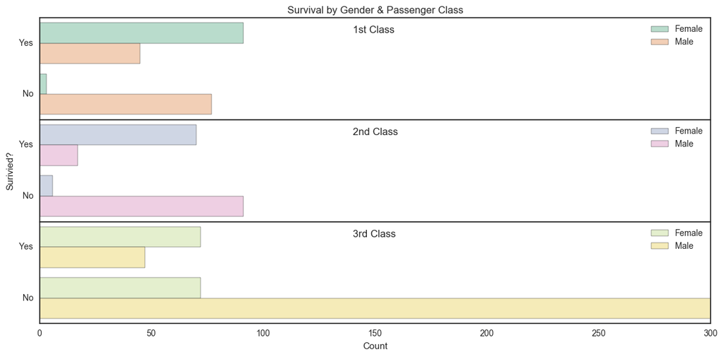

```python
# ----------------------------------------------------------------------
# - Plot `survived` by `sex` and `pclass`
# ----------------------------------------------------------------------

fig, axes = plt.subplots(3, 1, sharex=True, sharey=True)

pclasses = get_labels(titanic.pclass)
class_annotations = ['{} Class'.format(label)
                     for label in get_labels(titanic.pclass_label)]
cidx_pairs = [(0, 1), (2, 3), (4, 5)]
palette = sns.color_palette("Pastel2")

zipper = enumerate(zip(axes, pclasses, cidx_pairs, class_annotations))
for index, (ax, pclass, cidx_pair, class_annotation) in zipper:

    sns.countplot(y='survived_label', hue='sex_label',
                  data=titanic.loc[titanic.pclass == pclass, :],
                  order=get_labels(titanic.survived_label, False),
                  hue_order=get_labels(titanic.sex_label),
                  palette={'Female': palette[cidx_pair[0]],
                           'Male': palette[cidx_pair[1]]},
                  ax=ax)

    ax.annotate(class_annotation, (140, -0.2))
    ax.legend()

    if index == 0:
        ax.set_xlabel('')
        ax.set_ylabel('')
        ax.set_title('Survival by Gender & Passenger Class')
    elif index == 1:
        ax.set_xlabel('')
        ax.set_ylabel('Surivied?')
    elif index == 2:
        ax.set_xlabel('Count')
        ax.set_ylabel('')


fig.set_figwidth(12)
fig.set_figheight(6)
fig.set_tight_layout(tight={'h_pad': 0})

# ----------------------------------------------------------------------
```

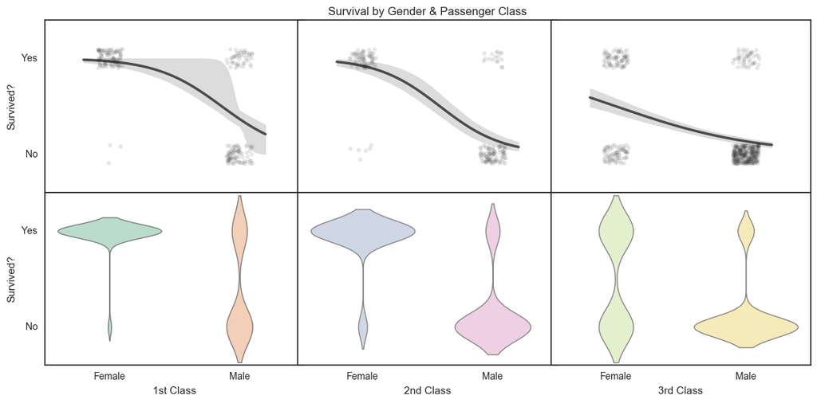

```python
# ----------------------------------------------------------------------
# - Plot `survived` by `pclass` and `sex`
# ----------------------------------------------------------------------

fig, axes = plt.subplots(2, 3, sharex=True, sharey=True)

# create the first row of plots
row_one = axes[0]

pclasses = get_labels(titanic.pclass)
survived_labels = get_labels(titanic.survived_label)
tick_labels = ['', '', survived_labels[0], '', '',
               '', '', survived_labels[1], '', '']

zipper1 = enumerate(zip(row_one, pclasses))
for index, (ax, pclass) in zipper1:
    sns.regplot(x="sex", y="survived",
                data=titanic.loc[titanic.pclass == pclass, :],
                scatter_kws={'alpha': 0.1, 'color': 'k'},
                line_kws={'alpha': 0.75, 'color': 'k'},
                logistic=True, n_boot=500, y_jitter=.1,
                x_jitter=.1, ax=ax)
    ax.set_xlabel('')
    ax.set_ylabel('')
    if index == 0:
        ax.set_ylabel('Survived?')
        ax.set_yticklabels(tick_labels)
    elif index == 1:
        ax.set_ylabel('')
        ax.set_title('Survival by Gender & Passenger Class')
    else:
        ax.set_ylabel('')

# create the second row of plots
row_two = axes[1]

class_labels = get_labels(titanic.pclass_label)
sex_labels = get_labels(titanic.sex_label)

index_pairs = [[0, 1], [2, 3], [4, 5]]
palette = sns.color_palette("Pastel2")

zipper2 = enumerate(zip(row_two, pclasses, index_pairs, class_labels))
for index, (ax, pclass, index_pair, class_label) in zipper2:
    sns.violinplot(x="sex", y="survived",
                   palette={0: palette[index_pair[0]],
                            1: palette[index_pair[1]]},
                   data=titanic.loc[titanic.pclass == pclass, :],
                   ax=ax, inner=None, linewidth=1)
    ax.set_xlabel('{} Class'.format(class_label))
    ax.set_xticklabels(sex_labels)
    if index == 0:
        ax.set_ylabel('Survived?')
        ax.set_yticklabels(tick_labels)
    else:
        ax.set_ylabel('')


fig.set_figwidth(12)
fig.set_figheight(6)
fig.set_tight_layout(tight={'h_pad': 0, 'w_pad': -1})

# ----------------------------------------------------------------------
```

This pair of plots gives us a similar view. It's interesting how well the absolute numbers, results of logistic regression, and the density shown in the violin plots line up: survival is much more likely in high-status, female passengers, and the benefit of being female decreases sharply on the division between second and third class.

```python
# ----------------------------------------------------------------------
# - Get summary statistics for `survived` by `age_range`
# ----------------------------------------------------------------------

stats = (titanic.groupby(['age_range'])['survived']
                .agg(['mean', 'count']))
stats['mean'] = stats['mean'].apply(format_pct)
stats.columns = ['Mean Survival', 'Passengers Count']
stats.index.name = (stats.index.name.replace('_', ' ').title())

print "Summary of Survival by Passenger Age Range:\n"
print stats

# ----------------------------------------------------------------------
```

```
Summary of Survival by Passenger Age Range:

          Mean Survival  Passengers Count
Age Range
0 to 5           70.45%                44
5 to 10          35.00%                20
10 to 15         57.89%                19
15 to 20         34.38%                96
20 to 25         34.43%               122
25 to 30         38.89%               108
30 to 35         46.59%                88
35 to 40         41.79%                67
40 to 45         36.17%                47
45 to 50         41.03%                39
50 to 55         41.67%                24
55 to 60         38.89%                18
60 to 65         28.57%                14
65 to 70          0.00%                 3
70 to 75          0.00%                 4
75 to 80        100.00%                 1
```

Looking at age alone, we can see that very young children and younger teens had the highest rates of survival. While middle-aged passengers also had high rates of survival, this may be because of the impact of passenger class.

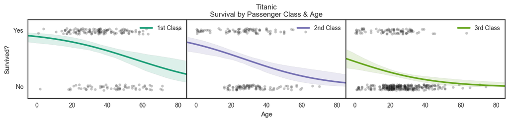

```python
# ----------------------------------------------------------------------
# - Plot `survived` by `pclass` and `age`
# ----------------------------------------------------------------------

fig, axes = plt.subplots(1, 3, sharex=True, sharey=True)

pclasses = [1, 2, 3]
colors = sns.color_palette('Dark2')[0:6:2]
class_labels = get_labels(titanic.pclass_label)
survived_labels = get_labels(titanic.survived_label)
tick_labels = ['', survived_labels[0], '', '',
               '', '', survived_labels[1], '']

zipper = enumerate(zip(axes, pclasses, colors, class_labels))
for index, (ax, pclass, color, class_label) in zipper:
    sns.regplot(x="age", y="survived",
                data=titanic.loc[titanic.pclass == pclass, :],
                n_boot=500, logistic=True, x_jitter=.05, y_jitter=.05,
                scatter_kws={'alpha': 0.25,
                             'color': 'k'},
                line_kws={'color': color,
                          'label': '{} Class'.format(class_label)},
                ax=ax)
    ax.legend()
    ax.set_xlim(-5, 85)
    if index == 0:
        ax.set_xlabel('')
        ax.set_ylabel('Survived?')
        ax.set_yticklabels(tick_labels)
    elif index == 1:
        ax.set_xlabel('Age')
        ax.set_ylabel('')
        ax.set_title('Titanic\nSurvival by Passenger Class & Age')
    elif index == 2:
        ax.set_xlabel('')
        ax.set_ylabel('')

fig.set_figwidth(12)
fig.set_figheight(3)
fig.set_tight_layout(tight={'w_pad': 0})

# ----------------------------------------------------------------------
```

Here we're using logistic regression to look at age in combination with passenger class. There appears to be a relationship between age and survival, and that relationship appears to be stronger with increasingly high-status passenger class.

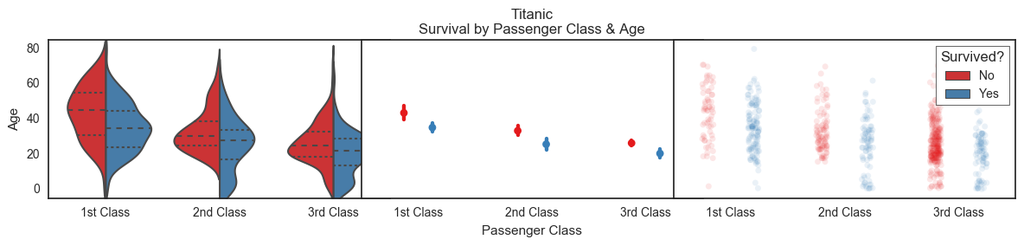

```python
# ----------------------------------------------------------------------
# - Plot `survived` by `pclass` and `age`
# ----------------------------------------------------------------------

fig, axes = plt.subplots(1, 3, sharex=True, sharey=True)

# set paramaters common to all plots
palette = sns.color_palette('Set1')

plots = [functools.partial(plot, x='pclass', y='age',
                           hue='survived', hue_order=[0, 1],
                           data=titanic, palette=palette)
         for plot in [sns.violinplot, sns.pointplot, sns.stripplot]]

tick_labels = ['{} Class'.format(label)
               for label in get_labels(titanic.pclass_label)]
survived_labels = get_labels(titanic.survived_label)

zipper = enumerate(zip(axes, plots))
for index, (ax, plot) in zipper:
    if index == 0:
        plot(split=True, linewidth=1.5, inner='quartile', ax=ax)

        handles, _ = ax.get_legend_handles_labels()
        ax.legend([])
        ax.set_xlabel('')
        ax.set_ylabel('Age')
    elif index == 1:
        plot(dodge=0.25, join=False, markers=['.', '.'], ax=ax)

        ax.legend([])
        ax.set_title('Titanic\nSurvival by Passenger Class & Age')
        ax.set_xlabel('Passenger Class')
        ax.set_ylabel('')
    elif index == 2:
        plot(split=True,   jitter=True, alpha=0.1, ax=ax)

        ax.legend(handles, survived_labels,
                  title='Survived?', frameon=True)
        ax.get_legend().get_frame().set_linewidth(0.5)
        ax.set_xlabel('')
        ax.set_ylabel('')
    ax.set_xticklabels(tick_labels)
    ax.set_ylim(-5, 85)


fig.set_figwidth(12)
fig.set_figheight(3)
fig.set_tight_layout(tight={'w_pad': -2})

# ----------------------------------------------------------------------
```

A slightly more intuitive method than logistic regression, both the median (i.e. violin-plot center lines) and mean (i.e. point plot dots) show a clear relationship across age and passenger class. The relationship is even apparrent in the jitter plot at the right.

## Conclusion

Before we wrap up, let's have an explicit look at the correlation between the variables we've explored:

```python
# ----------------------------------------------------------------------
# - Summarize correlation between explored variables
# ----------------------------------------------------------------------

correlation = (titanic.loc[:, ['sex', 'age', 'pclass', 'survived']]
                      .corr()
                      .applymap(format_float))
correlation.columns = ['Gender', 'Age', 'Passenger Class', 'Surived?']
correlation.index = ['Gender', 'Age', 'Passenger Class', 'Survived?']

print "Summary of Correlation Between Explored Variables:\n"
print correlation

# ----------------------------------------------------------------------
```

```
Summary of Correlation Between Explored Variables:

                Gender    Age Passenger Class Surived?
Gender            1.00   0.09            0.13    -0.54
Age               0.09   1.00           -0.37    -0.08
Passenger Class   0.13  -0.37            1.00    -0.34
Survived?        -0.54  -0.08           -0.34     1.00
```

This fits nicely with what we've seen so far:

- Increased survival is associated with decreased gender (i.e. surviving passengers are more likely to be female)
- Increased survival is associated with decreased passenger class (i.e. closer to 1st, the highest-status class)
- Increased survival is only weakly associated with passenger age
- Increased passenger class is weakly associated with increased gender (i.e. lower class passengers are more likely to be male)
- Increased passenger class is associated with decreased age (i.e. lower class passengers are younger)
- Increased age is weakly associated with increased gender (i.e. older passengers are slightly more likely to be male)

It's quite tempting to speak of causes when we explore in this fashion:

- Higher-status passengers received preferential access to lifeboats!
- Women and children received preferential access to lifeboats!
- Older passengers with more personal resources were more likely to be able to afford first and second class!

However, such conclusions are premature: they're really better-phrased as questions. Having useful questions to ask is, in fact, one of the best outcomes of data exploration. In this project we've gained a better undertanding of the relationships between gender, age, passenger class, and survival on the Titanic, and we have a place to start for either digging into the historical reasons for these relationships or modeling the relationships between the variables with machine learning.

## References

- http://pandas.pydata.org/pandas-docs/stable/
- http://matplotlib.org/contents.html
- http://seaborn.pydata.org/api.html
- https://en.wikipedia.org/wiki/RMS_Titanic
- https://www.kaggle.com/c/titanic/data